# Project: Analysing TMDb Dataset

## Introduction

I chose The TMDb Movie Data Set for data analysis. It contains information about 10,000 movies collected from the Movie Database(TMDb), including user ratings and revenue. In my analysis, I would like to check other interesting parts of the dataset.

```python
# I will use this cell to import statements of all the packages I intend to use for the project
import pandas as pd
import numpy as np
import matplotlib.pyplot as plt
import seaborn as sns
%matplotlib inline
```

## Data Wrangling

```python
# Load data. View the first five rows
movies_df=pd.read_csv('tmdb_movies_data.csv')
movies_df.head()
```

|  | id | imdb_id | popularity | budget | revenue | original_title | cast | homepage | director | tagline | ... | overview | runtime | genres | production_companies | release_date | vote_count | vote_average | release_year | budget_adj | revenue_adj |
| --- | --- | --- | --- | --- | --- | --- | --- | --- | --- | --- | --- | --- | --- | --- | --- | --- | --- | --- | --- | --- | --- |
| 0 | 135397 | tt0369610 | 32.985763 | 150000000 | 1513528810 | Jurassic World | Chris Pratt\|Bryce Dallas Howard\|Irrfan Khan\|Vi... | http://www.jurassicworld.com/ | Colin Trevorrow | The park is open. | ... | Twenty-two years after the events of Jurassic ... | 124 | Action\|Adventure\|Science Fiction\|Thriller | Universal Studios\|Amblin Entertainment\|Legenda... | 6/9/2015 | 5562 | 6.5 | 2015 | 137999939.3 | 1.392446e+09 |
| 1 | 76341 | tt1392190 | 28.419936 | 150000000 | 378436354 | Mad Max: Fury Road | Tom Hardy\|Charlize Theron\|Hugh Keays-Byrne\|Nic... | http://www.madmaxmovie.com/ | George Miller | What a Lovely Day. | ... | An apocalyptic story set in the furthest reach... | 120 | Action\|Adventure\|Science Fiction\|Thriller | Village Roadshow Pictures\|Kennedy Miller Produ... | 5/13/2015 | 6185 | 7.1 | 2015 | 137999939.3 | 3.481613e+08 |
| 2 | 262500 | tt2908446 | 13.112507 | 110000000 | 295238201 | Insurgent | Shailene Woodley\|Theo James\|Kate Winslet\|Ansel... | http://www.thedivergentseries.movie/#insurgent | Robert Schwentke | One Choice Can Destroy You | ... | Beatrice Prior must confront her inner demons ... | 119 | Adventure\|Science Fiction\|Thriller | Summit Entertainment\|Mandeville Films\|Red Wago... | 3/18/2015 | 2480 | 6.3 | 2015 | 101199955.5 | 2.716190e+08 |
| 3 | 140607 | tt2488496 | 11.173104 | 200000000 | 2068178225 | Star Wars: The Force Awakens | Harrison Ford\|Mark Hamill\|Carrie Fisher\|Adam D... | http://www.starwars.com/films/star-wars-episod... | J.J. Abrams | Every generation has a story. | ... | Thirty years after defeating the Galactic Empi... | 136 | Action\|Adventure\|Science Fiction\|Fantasy | Lucasfilm\|Truenorth Productions\|Bad Robot | 12/15/2015 | 5292 | 7.5 | 2015 | 183999919.0 | 1.902723e+09 |
| 4 | 168259 | tt2820852 | 9.335014 | 190000000 | 1506249360 | Furious 7 | Vin Diesel\|Paul Walker\|Jason Statham\|Michelle ... | http://www.furious7.com/ | James Wan | Vengeance Hits Home | ... | Deckard Shaw seeks revenge against Dominic Tor... | 137 | Action\|Crime\|Thriller | Universal Pictures\|Original Film\|Media Rights ... | 4/1/2015 | 2947 | 7.3 | 2015 | 174799923.1 | 1.385749e+09 |

5 rows × 21 columns

```python
# In this cell, I will explore data by name of columns to determine the wanted and unwanted data for the analysis
movies_df.columns
```

```
Index(['id', 'imdb_id', 'popularity', 'budget', 'revenue', 'original_title',
       'cast', 'homepage', 'director', 'tagline', 'keywords', 'overview',
       'runtime', 'genres', 'production_companies', 'release_date',
       'vote_count', 'vote_average', 'release_year', 'budget_adj',
       'revenue_adj'],
      dtype='object')
```

```python
# number of rows and columns in the dataset
movies_df.shape
```

```
(10866, 21)
```

```python
# I will show the number of samples and information about the dataset to assess whether there are missing values or not.
movies_df.info()
```

```
<class 'pandas.core.frame.DataFrame'>
RangeIndex: 10866 entries, 0 to 10865
Data columns (total 21 columns):
 #   Column                Non-Null Count  Dtype
---  ------                --------------  -----
 0   id                    10866 non-null  int64
 1   imdb_id               10856 non-null  object
 2   popularity            10866 non-null  float64
 3   budget                10866 non-null  int64
 4   revenue               10866 non-null  int64
 5   original_title        10866 non-null  object
 6   cast                  10790 non-null  object
 7   homepage              2936 non-null   object
 8   director              10822 non-null  object
 9   tagline               8042 non-null   object
 10  keywords              9373 non-null   object
 11  overview              10862 non-null  object
 12  runtime               10866 non-null  int64
 13  genres                10843 non-null  object
 14  production_companies  9836 non-null   object
 15  release_date          10866 non-null  object
 16  vote_count            10866 non-null  int64
 17  vote_average          10866 non-null  float64
 18  release_year          10866 non-null  int64
 19  budget_adj            10866 non-null  float64
 20  revenue_adj           10866 non-null  float64
dtypes: float64(4), int64(6), object(11)
memory usage: 1.7+ MB
```

```python
# In this cell I will take the descriptive statistics to sumerize the dataset
movies_df.describe()
```

|  | id | popularity | budget | revenue | runtime | vote_count | vote_average | release_year | budget_adj | revenue_adj |
| --- | --- | --- | --- | --- | --- | --- | --- | --- | --- | --- |
| count | 10866.000000 | 10866.000000 | 1.086600e+04 | 1.086600e+04 | 10866.000000 | 10866.000000 | 10866.000000 | 10866.000000 | 1.086600e+04 | 1.086600e+04 |
| mean | 66064.177434 | 0.646441 | 1.462570e+07 | 3.982332e+07 | 102.070863 | 217.389748 | 5.974922 | 2001.322658 | 1.755104e+07 | 5.136436e+07 |
| std | 92130.136561 | 1.000185 | 3.091321e+07 | 1.170035e+08 | 31.381405 | 575.619058 | 0.935142 | 12.812941 | 3.430616e+07 | 1.446325e+08 |
| min | 5.000000 | 0.000065 | 0.000000e+00 | 0.000000e+00 | 0.000000 | 10.000000 | 1.500000 | 1960.000000 | 0.000000e+00 | 0.000000e+00 |
| 25% | 10596.250000 | 0.207583 | 0.000000e+00 | 0.000000e+00 | 90.000000 | 17.000000 | 5.400000 | 1995.000000 | 0.000000e+00 | 0.000000e+00 |
| 50% | 20669.000000 | 0.383856 | 0.000000e+00 | 0.000000e+00 | 99.000000 | 38.000000 | 6.000000 | 2006.000000 | 0.000000e+00 | 0.000000e+00 |
| 75% | 75610.000000 | 0.713817 | 1.500000e+07 | 2.400000e+07 | 111.000000 | 145.750000 | 6.600000 | 2011.000000 | 2.085325e+07 | 3.369710e+07 |
| max | 417859.000000 | 32.985763 | 4.250000e+08 | 2.781506e+09 | 900.000000 | 9767.000000 | 9.200000 | 2015.000000 | 4.250000e+08 | 2.827124e+09 |

## Data Cleaning

```python
# First, I will drop the columns that will not be needed in my analsis.
movies_df.drop(['id', 'imdb_id', 'homepage', 'tagline', 'overview', 'production_companies', 'budget_adj', 'revenue_adj','keywords'], axis=1, inplace=True)
```

```python
# View the first five rows after the modification
movies_df.head()
```

|  | popularity | budget | revenue | original_title | cast | director | runtime | genres | release_date | vote_count | vote_average | release_year |
| --- | --- | --- | --- | --- | --- | --- | --- | --- | --- | --- | --- | --- |
| 0 | 32.985763 | 150000000 | 1513528810 | Jurassic World | Chris Pratt\|Bryce Dallas Howard\|Irrfan Khan\|Vi... | Colin Trevorrow | 124 | Action\|Adventure\|Science Fiction\|Thriller | 6/9/2015 | 5562 | 6.5 | 2015 |
| 1 | 28.419936 | 150000000 | 378436354 | Mad Max: Fury Road | Tom Hardy\|Charlize Theron\|Hugh Keays-Byrne\|Nic... | George Miller | 120 | Action\|Adventure\|Science Fiction\|Thriller | 5/13/2015 | 6185 | 7.1 | 2015 |
| 2 | 13.112507 | 110000000 | 295238201 | Insurgent | Shailene Woodley\|Theo James\|Kate Winslet\|Ansel... | Robert Schwentke | 119 | Adventure\|Science Fiction\|Thriller | 3/18/2015 | 2480 | 6.3 | 2015 |
| 3 | 11.173104 | 200000000 | 2068178225 | Star Wars: The Force Awakens | Harrison Ford\|Mark Hamill\|Carrie Fisher\|Adam D... | J.J. Abrams | 136 | Action\|Adventure\|Science Fiction\|Fantasy | 12/15/2015 | 5292 | 7.5 | 2015 |
| 4 | 9.335014 | 190000000 | 1506249360 | Furious 7 | Vin Diesel\|Paul Walker\|Jason Statham\|Michelle ... | James Wan | 137 | Action\|Crime\|Thriller | 4/1/2015 | 2947 | 7.3 | 2015 |

```python
# view the last five rows in the dataset
movies_df.tail()
```

|  | popularity | budget | revenue | original_title | cast | director | runtime | genres | release_date | vote_count | vote_average | release_year |
| --- | --- | --- | --- | --- | --- | --- | --- | --- | --- | --- | --- | --- |
| 10861 | 0.080598 | 0 | 0 | The Endless Summer | Michael Hynson\|Robert August\|Lord 'Tally Ho' B... | Bruce Brown | 95 | Documentary | 6/15/1966 | 11 | 7.4 | 1966 |
| 10862 | 0.065543 | 0 | 0 | Grand Prix | James Garner\|Eva Marie Saint\|Yves Montand\|Tosh... | John Frankenheimer | 176 | Action\|Adventure\|Drama | 12/21/1966 | 20 | 5.7 | 1966 |
| 10863 | 0.065141 | 0 | 0 | Beregis Avtomobilya | Innokentiy Smoktunovskiy\|Oleg Efremov\|Georgi Z... | Eldar Ryazanov | 94 | Mystery\|Comedy | 1/1/1966 | 11 | 6.5 | 1966 |
| 10864 | 0.064317 | 0 | 0 | What's Up, Tiger Lily? | Tatsuya Mihashi\|Akiko Wakabayashi\|Mie Hama\|Joh... | Woody Allen | 80 | Action\|Comedy | 11/2/1966 | 22 | 5.4 | 1966 |
| 10865 | 0.035919 | 19000 | 0 | Manos: The Hands of Fate | Harold P. Warren\|Tom Neyman\|John Reynolds\|Dian... | Harold P. Warren | 74 | Horror | 11/15/1966 | 15 | 1.5 | 1966 |

```python
# After showing the last few rows, I realized that some values in the revenue and budget are zeros. In this cell, I decided to drop them.
movies_df.drop(movies_df[movies_df['revenue']==0].index, inplace=True)
movies_df.drop(movies_df[movies_df['budget']==0].index, inplace=True)
movies_df.head()
```

|  | popularity | budget | revenue | original_title | cast | director | runtime | genres | release_date | vote_count | vote_average | release_year |
| --- | --- | --- | --- | --- | --- | --- | --- | --- | --- | --- | --- | --- |
| 0 | 32.985763 | 150000000 | 1513528810 | Jurassic World | Chris Pratt\|Bryce Dallas Howard\|Irrfan Khan\|Vi... | Colin Trevorrow | 124 | Action\|Adventure\|Science Fiction\|Thriller | 6/9/2015 | 5562 | 6.5 | 2015 |
| 1 | 28.419936 | 150000000 | 378436354 | Mad Max: Fury Road | Tom Hardy\|Charlize Theron\|Hugh Keays-Byrne\|Nic... | George Miller | 120 | Action\|Adventure\|Science Fiction\|Thriller | 5/13/2015 | 6185 | 7.1 | 2015 |
| 2 | 13.112507 | 110000000 | 295238201 | Insurgent | Shailene Woodley\|Theo James\|Kate Winslet\|Ansel... | Robert Schwentke | 119 | Adventure\|Science Fiction\|Thriller | 3/18/2015 | 2480 | 6.3 | 2015 |
| 3 | 11.173104 | 200000000 | 2068178225 | Star Wars: The Force Awakens | Harrison Ford\|Mark Hamill\|Carrie Fisher\|Adam D... | J.J. Abrams | 136 | Action\|Adventure\|Science Fiction\|Fantasy | 12/15/2015 | 5292 | 7.5 | 2015 |
| 4 | 9.335014 | 190000000 | 1506249360 | Furious 7 | Vin Diesel\|Paul Walker\|Jason Statham\|Michelle ... | James Wan | 137 | Action\|Crime\|Thriller | 4/1/2015 | 2947 | 7.3 | 2015 |

```python
# Check whether the duplicate values exists in the data set
movies_df.duplicated().any()
```

```
True
```

```python
# In this cell, I removed the duplicate values in the dataset
movies_df.drop_duplicates(inplace=True)
```

```python
# i confirmed to determine the duplicates were removed
movies_df.duplicated().any()
```

```
False
```

```python
#checking the missing values in the dataset
movies_df.isnull().sum()
```

```
popularity        0
budget            0
revenue           0
original_title    0
cast              4
director          1
runtime           0
genres            0
release_date      0
vote_count        0
vote_average      0
release_year      0
dtype: int64
```

```python
# In this cell, I will drop the misssing values
movies_df.dropna(subset=['director', 'cast'], axis=0, inplace=True)
```

```python
#confirm if the missing values were dropped.
movies_df.isnull().sum()
```

```
popularity        0
budget            0
revenue           0
original_title    0
cast              0
director          0
runtime           0
genres            0
release_date      0
vote_count        0
vote_average      0
release_year      0
dtype: int64
```

```python
# Check the status of the dataset after cleaning by showing the first view rows
movies_df.head(7)
```

|  | popularity | budget | revenue | original_title | cast | director | runtime | genres | release_date | vote_count | vote_average | release_year |
| --- | --- | --- | --- | --- | --- | --- | --- | --- | --- | --- | --- | --- |
| 0 | 32.985763 | 150000000 | 1513528810 | Jurassic World | Chris Pratt\|Bryce Dallas Howard\|Irrfan Khan\|Vi... | Colin Trevorrow | 124 | Action\|Adventure\|Science Fiction\|Thriller | 6/9/2015 | 5562 | 6.5 | 2015 |
| 1 | 28.419936 | 150000000 | 378436354 | Mad Max: Fury Road | Tom Hardy\|Charlize Theron\|Hugh Keays-Byrne\|Nic... | George Miller | 120 | Action\|Adventure\|Science Fiction\|Thriller | 5/13/2015 | 6185 | 7.1 | 2015 |
| 2 | 13.112507 | 110000000 | 295238201 | Insurgent | Shailene Woodley\|Theo James\|Kate Winslet\|Ansel... | Robert Schwentke | 119 | Adventure\|Science Fiction\|Thriller | 3/18/2015 | 2480 | 6.3 | 2015 |
| 3 | 11.173104 | 200000000 | 2068178225 | Star Wars: The Force Awakens | Harrison Ford\|Mark Hamill\|Carrie Fisher\|Adam D... | J.J. Abrams | 136 | Action\|Adventure\|Science Fiction\|Fantasy | 12/15/2015 | 5292 | 7.5 | 2015 |
| 4 | 9.335014 | 190000000 | 1506249360 | Furious 7 | Vin Diesel\|Paul Walker\|Jason Statham\|Michelle ... | James Wan | 137 | Action\|Crime\|Thriller | 4/1/2015 | 2947 | 7.3 | 2015 |
| 5 | 9.110700 | 135000000 | 532950503 | The Revenant | Leonardo DiCaprio\|Tom Hardy\|Will Poulter\|Domhn... | Alejandro González Iñárritu | 156 | Western\|Drama\|Adventure\|Thriller | 12/25/2015 | 3929 | 7.2 | 2015 |
| 6 | 8.654359 | 155000000 | 440603537 | Terminator Genisys | Arnold Schwarzenegger\|Jason Clarke\|Emilia Clar... | Alan Taylor | 125 | Science Fiction\|Action\|Thriller\|Adventure | 6/23/2015 | 2598 | 5.8 | 2015 |

## Exploring Data Analysis by Visualization

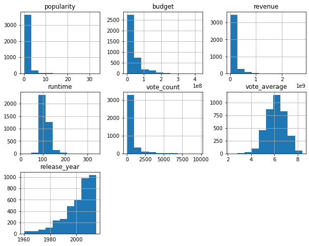

```python
# Here I explored the entire data set.
movies_df.hist(figsize=(10,8));
```

explore data by pivot_table

```python
pivot_table = movies_df[['original_title','revenue', 'release_year']]
pivot_group = pivot_table.groupby(['original_title','revenue'],as_index=False).mean()
```

Show the corrolation between the tables

```python
movies_df.corr()
```

|  | popularity | budget | revenue | runtime | vote_count | vote_average | release_year |
| --- | --- | --- | --- | --- | --- | --- | --- |
| popularity | 1.000000 | 0.446563 | 0.615348 | 0.215510 | 0.779986 | 0.317750 | 0.173599 |
| budget | 0.446563 | 1.000000 | 0.688403 | 0.261489 | 0.556681 | 0.023638 | 0.268464 |
| revenue | 0.615348 | 0.688403 | 1.000000 | 0.250728 | 0.754466 | 0.227071 | 0.139316 |
| runtime | 0.215510 | 0.261489 | 0.250728 | 1.000000 | 0.274215 | 0.352615 | -0.112954 |
| vote_count | 0.779986 | 0.556681 | 0.754466 | 0.274215 | 1.000000 | 0.387262 | 0.207462 |
| vote_average | 0.317750 | 0.023638 | 0.227071 | 0.352615 | 0.387262 | 1.000000 | -0.133315 |
| release_year | 0.173599 | 0.268464 | 0.139316 | -0.112954 | 0.207462 | -0.133315 | 1.000000 |

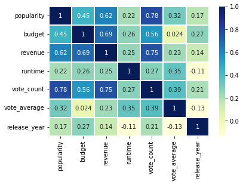

```python
# map the corrolation
sns.heatmap(movies_df.corr(), cmap='YlGnBu', annot=True, linewidths = 0.4);
```

Research Question One:

```
Which movie has the highest vote rate?
```

```python
# I reorganized the data by vote average then compare the the first five movies to pick the best
high_vote_rate = movies_df.sort_values(by='vote_average',ascending = False)
high_vote_rate[['original_title','vote_average']].head()
```

|  | original_title | vote_average |
| --- | --- | --- |
| 7948 | Stop Making Sense | 8.4 |
| 4178 | The Shawshank Redemption | 8.4 |
| 7269 | The Godfather | 8.3 |
| 650 | Whiplash | 8.2 |
| 2875 | The Dark Knight | 8.1 |

> According to my obsevation in my analysis, 'Stop Making Sense' and The 'Shawsshank Redemption' are the best movies with a vote average of 8.4

Question Two:

```
What is the bottom 8 movies by popularity?
```

```python
# check the unpopular value
movies_df.popularity.min()
```

```
0.001117
```

```python
# In this cell, I discovered my data to collect between popularity and movies names.
unpopular_movies=movies_df.pivot_table(values='popularity',index="original_title").sort_values(ascending=True,by='popularity').head(8)
unpopular_movies
```

| original_title | popularity |
| --- | --- |
| Born into Brothels | 0.001117 |
| Ð¡Ñ‚Ð°Ð»Ð¸Ð½Ð³Ñ€Ð°Ð´ | 0.010335 |
| Spacehunter: Adventures in the Forbidden Zone | 0.015727 |
| The In Crowd | 0.015997 |
| The Bad News Bears | 0.017498 |
| The Kid Stays in the Picture | 0.017708 |
| Top Dog | 0.018196 |
| No End in Sight | 0.019101 |

```python
def label(x,y,t):
    """
    Args:
    x(str):x-axis title
    y(str):y-axis title
    t(str):main title

    Return:
    None
    """

    plt.xlabel(x)
    plt.ylabel(y)
    plt.title(t)
    plt.show()
```

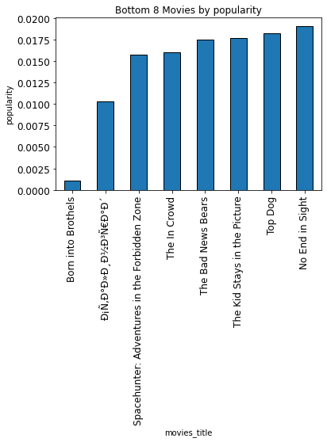

```python
# visualize the data
unpopular_movies.popularity.plot(kind='bar',fontsize=12,edgecolor='black')
label('movies_title','popularity','Bottom 8 Movies by popularity')
```

Results

-The above analysis shows the bottom 8 movies by popularity

-After the analysis, I was able to find out that Born into the Brothels is the unpopular movie in the world

Question Three:

```
  What is the top Six revenue movies?
```

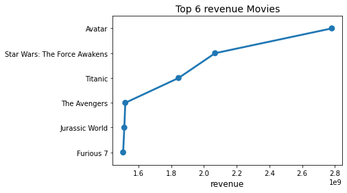

```python
top_revenues = pd.DataFrame(movies_df['revenue'].sort_values(ascending = False))
top_revenues['original_title'] = movies_df['original_title']
data = list(map(str,(top_revenues['original_title'])))
x = list(data[:6])
y = list(top_revenues['revenue'][:6])

# make a plot using pointplot for top 6 revenue movies.
ax = sns.pointplot(x=y,y=x)

#setup the figure size
sns.set(rc={'figure.figsize':(10,5)})
#setup the title and labels of the plot.
ax.set_title("Top 6 revenue Movies",fontsize = 14)
ax.set_xlabel("revenue",fontsize = 12)
sns.set_style("darkgrid")
```

After the analysis above, I was able to realize Avatar is the top most movie by revenue hence the most profitable movie in the world.

Question Four:

```
 What is the effect of the film budget over time in the first 35 years?
```

```python
# In this cell, I made pivot table to  connect between year overtime and Budget.
annual_budget=movies_df.pivot_table(values='budget',index='release_year').head(35)
annual_budget
```

| release_year | budget |
| --- | --- |
| 1960 | 4.161390e+06 |
| 1961 | 3.863700e+06 |
| 1962 | 5.635714e+06 |
| 1963 | 1.018583e+07 |
| 1964 | 4.847880e+06 |
| 1965 | 1.176000e+07 |
| 1966 | 6.453600e+06 |
| 1967 | 7.346154e+06 |
| 1968 | 5.994444e+06 |
| 1969 | 5.711022e+06 |
| 1970 | 8.718359e+06 |
| 1971 | 3.077077e+06 |
| 1972 | 2.958032e+06 |
| 1973 | 4.777250e+06 |
| 1974 | 5.352692e+06 |
| 1975 | 4.122222e+06 |
| 1976 | 8.033333e+06 |
| 1977 | 7.307895e+06 |
| 1978 | 9.774707e+06 |
| 1979 | 1.441875e+07 |
| 1980 | 1.391522e+07 |
| 1981 | 9.725000e+06 |
| 1982 | 1.322692e+07 |
| 1983 | 1.565248e+07 |
| 1984 | 1.364398e+07 |
| 1985 | 1.454331e+07 |
| 1986 | 1.310625e+07 |
| 1987 | 1.323761e+07 |
| 1988 | 1.448750e+07 |
| 1989 | 1.898018e+07 |
| 1990 | 2.257794e+07 |
| 1991 | 2.630000e+07 |
| 1992 | 2.289293e+07 |
| 1993 | 2.223174e+07 |
| 1994 | 2.933560e+07 |

[figure not shown]

```python
# visualize the analysis
annual_budget.plot(kind='line' , fontsize='14')
label('release_year','budget','The degree of budget effect on films over the last 35 years')
```

**Results**

1. The above analysis is a relationship between years and budget.
2. After the analysis, I realized that the buget was lower in the 1960-1975 as compared from 1975 onwards in first 35 years.
3. It is evident the movie industry developed steadly from 1975-1995 hence the increase in budget and productivity.

## Conclusions

Unpopular movies were found to have less popularity compared to the other movies.

Avatar movie was the most profitable movie

The budget of films in the earlier years were lower as compared to the later years

## Challenge

I also did find duplicates values. I didn't need those columns in my analysis whereby I dropped them to solve the problem.

## References

https://www.kaggle.com/dataset

https://www.datacamp.com